# Predic traffic volume in AZ

Highest traffic in I-10 Phoenix: Near Loop 101. Traffic count in that area tracked by ATR Station 100086. Need to forecast daily traffic volume

```r
rm(list = ls())
```

```r
library(dygraphs)
library(fpp3)
# read the data
origin = read.csv("AZ_traffic.csv")
```

```r
head(origin)
```

|  | Station_Id | Travel_Dir | Travel_Lane | Hour_Volume | datetime |
| --- | --- | --- | --- | --- | --- |
| 1 | 100002 | 3 | 1 | 275 | 2018-01-01 00:00:00 |
| 2 | 100002 | 3 | 1 | 234 | 2018-01-01 01:00:00 |
| 3 | 100002 | 3 | 1 | 187 | 2018-01-01 02:00:00 |
| 4 | 100002 | 3 | 1 | 98 | 2018-01-01 03:00:00 |
| 5 | 100002 | 3 | 1 | 82 | 2018-01-01 04:00:00 |
| 6 | 100002 | 3 | 1 | 64 | 2018-01-01 05:00:00 |

```r
df <- origin |> filter(Station_Id == 100086)
```

```r
head(df)
```

|  | Station_Id | Travel_Dir | Travel_Lane | Hour_Volume | datetime |
| --- | --- | --- | --- | --- | --- |
| 1 | 100086 | 3 | 1 | 26 | 2018-01-11 00:00:00 |
| 2 | 100086 | 3 | 1 | 22 | 2018-01-11 01:00:00 |
| 3 | 100086 | 3 | 1 | 29 | 2018-01-11 02:00:00 |
| 4 | 100086 | 3 | 1 | 47 | 2018-01-11 03:00:00 |
| 5 | 100086 | 3 | 1 | 148 | 2018-01-11 04:00:00 |
| 6 | 100086 | 3 | 1 | 436 | 2018-01-11 05:00:00 |

```r
df[['datetime']] <- as.POSIXct(df[['datetime']],
                                   format = "%Y-%m-%d %H:%M:%S")
head(df)
```

|  | Station_Id | Travel_Dir | Travel_Lane | Hour_Volume | datetime |
| --- | --- | --- | --- | --- | --- |
| 1 | 100086 | 3 | 1 | 26 | 2018-01-11 00:00:00 |
| 2 | 100086 | 3 | 1 | 22 | 2018-01-11 01:00:00 |
| 3 | 100086 | 3 | 1 | 29 | 2018-01-11 02:00:00 |
| 4 | 100086 | 3 | 1 | 47 | 2018-01-11 03:00:00 |
| 5 | 100086 | 3 | 1 | 148 | 2018-01-11 04:00:00 |
| 6 | 100086 | 3 | 1 | 436 | 2018-01-11 05:00:00 |

```r
unique(df$Travel_Lane)
```

```
## [1] 1 2 3 4 5 6
```

```r
unique(df$Travel_Dir)
```

```
## [1] 3 7
```

```r
df <- df |> select(-c('Travel_Lane', 'Station_Id')) |>
  mutate(date=as.Date(datetime))
head(df)
```

|  | Travel_Dir | Hour_Volume | datetime | date |
| --- | --- | --- | --- | --- |
| 1 | 3 | 26 | 2018-01-11 00:00:00 | 2018-01-11 |
| 2 | 3 | 22 | 2018-01-11 01:00:00 | 2018-01-11 |
| 3 | 3 | 29 | 2018-01-11 02:00:00 | 2018-01-11 |
| 4 | 3 | 47 | 2018-01-11 03:00:00 | 2018-01-11 |
| 5 | 3 | 148 | 2018-01-11 04:00:00 | 2018-01-11 |
| 6 | 3 | 436 | 2018-01-11 05:00:00 | 2018-01-11 |

```r
df <- df |> select(-datetime) |>
      group_by(Travel_Dir, date) |>
      summarise(daily_volume = sum(Hour_Volume)) |>
      ungroup()
head(df)
```

| Travel_Dir | date | daily_volume |
| --- | --- | --- |
| 3 | 2018-01-01 | 43291 |
| 3 | 2018-01-02 | 99589 |
| 3 | 2018-01-03 | 98978 |
| 3 | 2018-01-04 | 96857 |
| 3 | 2018-01-05 | 98756 |
| 3 | 2018-01-06 | 87891 |

```r
df <- df |>
  as_tsibble(index = date,
             key = Travel_Dir)
```

```r
library(tsbox)
tsbox::ts_xts(df) |>
  dygraph() |>
  dyRangeSelector(dateWindow = c("2018-01-01", "2019-12-30"))
```

```
## Found numeric [id] column(s): 'Travel_Dir'.
## Are you using a wide data frame? To convert, use 'ts_long()'.
## Convert column(s) to character or factor to silence this message.
```

```
## [time]: 'date' [value]: 'daily_volume'
```

[interactive chart not shown]

We notice some unusually low traffic flow for some data points. After closer inspection, we observe that there are some missing dates in the time-series for which no traffic count is available. This is because ATR tracker was out of order in those days. In some cases, the tracker stopped functioning in the middle of the day. For those dates, we also observe very low traffic flow. That’s we will treat this partial records as missing values.

```r
threshold = 61000
errors <- df |>
  filter(daily_volume < threshold)
df <- df |> anti_join(errors)
df <- df |> fill_gaps()
```

```r
library(tsbox)
tsbox::ts_xts(df) |>
  dygraph() |>
  dyRangeSelector(dateWindow = c("2018-01-01", "2019-12-30"))
```

```
## Found numeric [id] column(s): 'Travel_Dir'.
## Are you using a wide data frame? To convert, use 'ts_long()'.
## Convert column(s) to character or factor to silence this message.
```

```
## [time]: 'date' [value]: 'daily_volume'
```

[interactive chart not shown]

```r
missing_data <- df |> filter(is.na(daily_volume))
```

```r
proxy <- origin |> filter(Station_Id == 100087)
proxy$date <- as.Date(proxy$datetime, format = "%Y-%m-%d")
proxy <- proxy |> select(-c('Travel_Lane', 'Station_Id'))
proxy <- proxy |> select(-datetime) |>
      group_by(Travel_Dir, date) |>
      summarise(daily_volume = sum(Hour_Volume)) |>
      ungroup()
proxy <- proxy |> as_tsibble(index = date, key = Travel_Dir)
```

```r
df <- df %>%
  left_join(proxy, by = c("date", "Travel_Dir"), suffix = c("", "_tsb2")) %>%
  mutate(daily_volume = coalesce(daily_volume, daily_volume_tsb2)) %>% # coalesce finds the first non-missing value
  select(-daily_volume_tsb2)

head(df)
```

| Travel_Dir | date | daily_volume |
| --- | --- | --- |
| 3 | 2018-01-02 | 99589 |
| 3 | 2018-01-03 | 98978 |
| 3 | 2018-01-04 | 96857 |
| 3 | 2018-01-05 | 98756 |
| 3 | 2018-01-06 | 87891 |
| 3 | 2018-01-07 | 75906 |

```r
library(tsbox)
tsbox::ts_xts(df) |>
  dygraph() |>
  dyRangeSelector(dateWindow = c("2018-01-01", "2019-12-30"))
```

```
## Found numeric [id] column(s): 'Travel_Dir'.
## Are you using a wide data frame? To convert, use 'ts_long()'.
## Convert column(s) to character or factor to silence this message.
```

```
## [time]: 'date' [value]: 'daily_volume'
```

[interactive chart not shown]

```r
df |> has_gaps()
```

| Travel_Dir | .gaps |
| --- | --- |
| 3 | FALSE |
| 7 | FALSE |

Data also missing in proxy

```r
na_count <- sum(is.na(df$daily_volume))
print(na_count)
```

```
## [1] 6
```

```r
df |> filter(is.na(daily_volume))
```

| Travel_Dir | date | daily_volume |
| --- | --- | --- |
| 3 | 2018-04-16 | NA |
| 3 | 2018-10-28 | NA |
| 3 | 2019-01-11 | NA |
| 7 | 2018-04-16 | NA |
| 7 | 2018-10-28 | NA |
| 7 | 2019-01-11 | NA |

```r
library(imputeTS)
# Impute missing values using linear interpolation
df <- df %>%
  group_by(Travel_Dir) %>%
  mutate(daily_volume = na_interpolation(daily_volume, option = "linear"))
```

```r
na_count <- sum(is.na(df$daily_volume))
print(na_count)
```

```
## [1] 0
```

```
## `mutate_if()` ignored the following grouping variables:
## • Column `Travel_Dir`
```

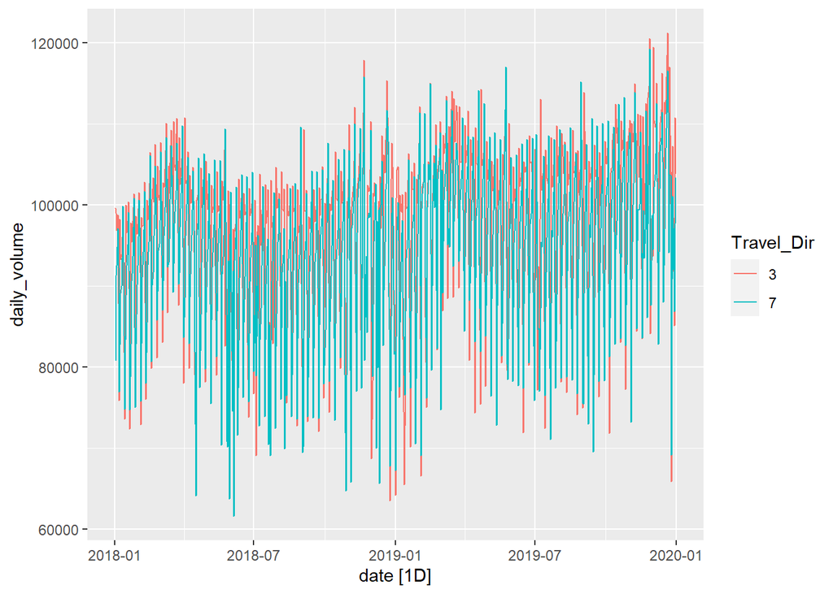

```r
df |>
  autoplot(daily_volume)
```

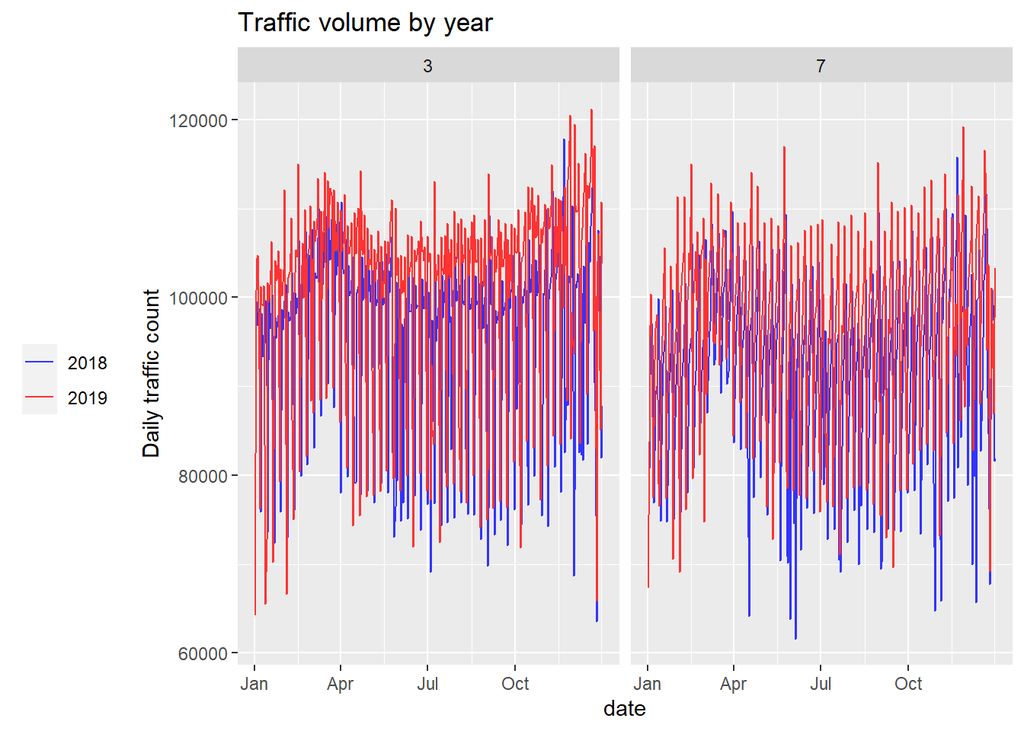

```r
df |>
  gg_season(daily_volume, period = "year", pal = c("#3333FF", "#FF3333")) +
  theme(legend.position = "left") +
  labs(y="Daily traffic count", title="Traffic volume by year") +
  facet_wrap(vars(Travel_Dir))
```

The annual pattern shows a uniform distribution of traffic flow throughout the year expect in March and April (due to tourism season) as well as in November and December (due to vacation period)

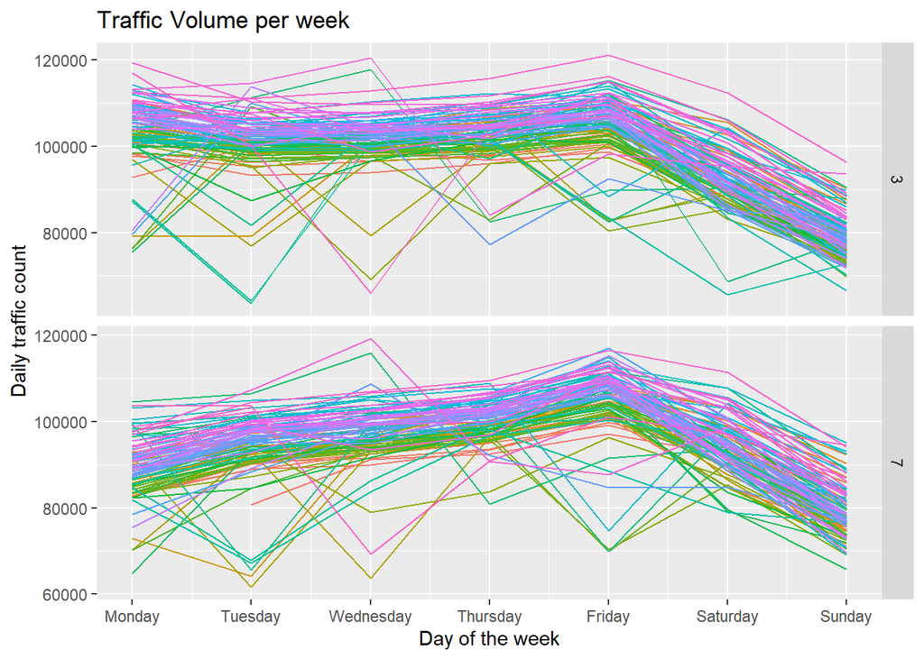

```r
df |>
  gg_season(daily_volume, period = "week") +
  theme(legend.position = "none") +
  labs(y="Daily traffic count", x="Day of the week", title="Traffic Volume per week")
```

We notice weakly seasonality. Traffic count on weekend is a significantly lower than weekdays.

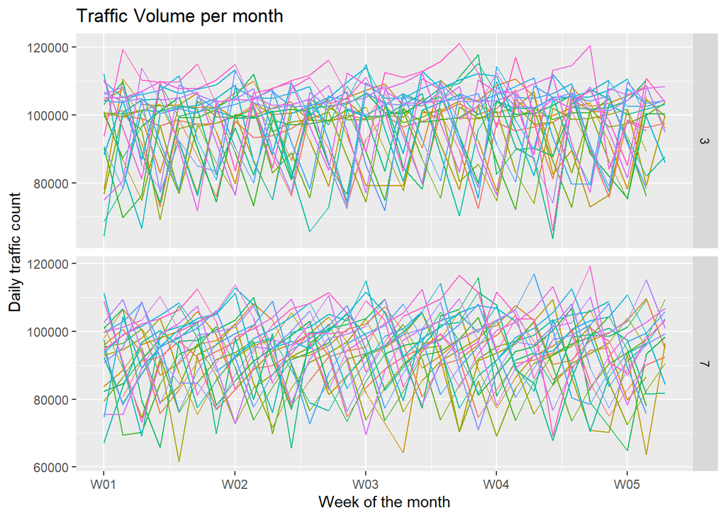

```r
df |>
  gg_season(daily_volume, period = "month") +
  theme(legend.position = "none") +
  labs(y="Daily traffic count", x="Week of the month", title="Traffic Volume per month")
```

No monthly seasonality can be observed

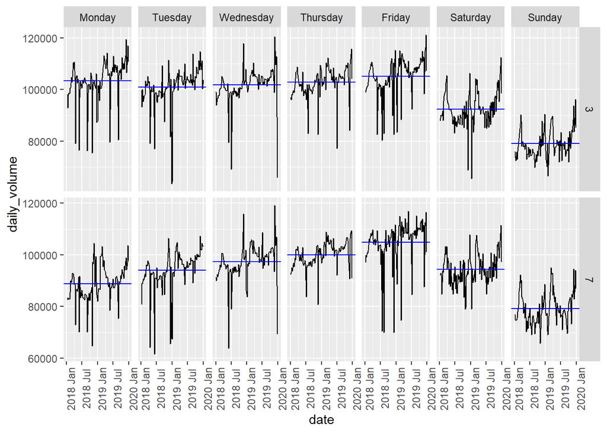

```r
df |>
  gg_subseries(daily_volume, period = 'week')
```

Same weakly pattern as seasonal plot. Less traffic on weekends. Using multiple plots, we confirm the presence of weekly seasonality

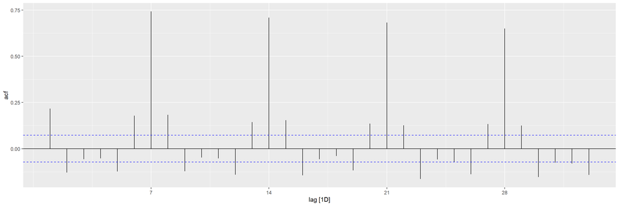

```r
df |> filter(Travel_Dir == '3') |>
  ACF(daily_volume, lag_max = 33) |> autoplot()
```

The autocorrelation plot also suggests the presence of weekly seasonality

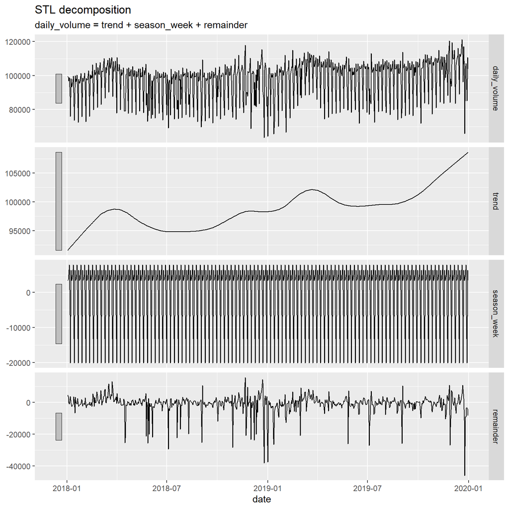

```r
dcmp <- df |> filter(Travel_Dir == '3') |>
  model(STL(daily_volume ~ trend(window=120) + season("week", window='periodic'), robust=TRUE)) #trend(window = 90) + season('week', window=30)))
components(dcmp)|> autoplot()
```

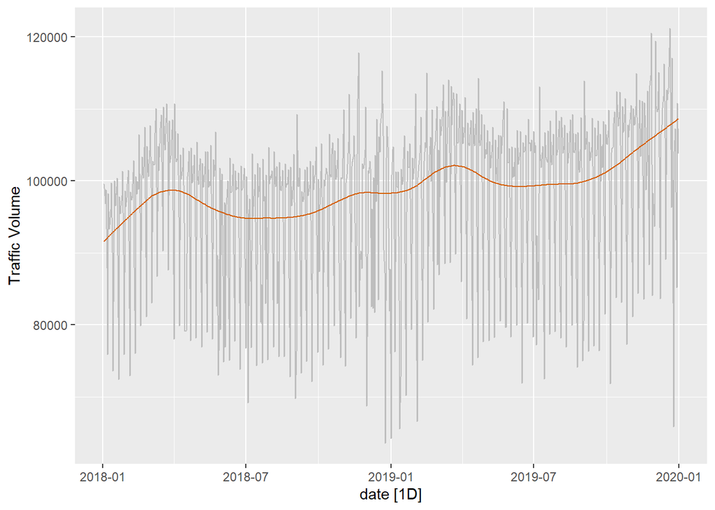

```r
components(dcmp) |>
  as_tsibble() |>
  autoplot(daily_volume, colour="gray") +
  geom_line(aes(y=trend), colour = "#D55E00") +
  labs(
    y = "Traffic Volume"
  )
```

```r
df |>
  features(daily_volume, feat_stl)
```

| Travel_Dir | trend_strength | seasonal_strength_week | seasonal_peak_week | seasonal_trough_week | spikiness | linearity | curvature | stl_e_acf1 | stl_e_acf10 |
| --- | --- | --- | --- | --- | --- | --- | --- | --- | --- |
| 3 | 0.5000482 | 0.8060683 | 0 | 6 | 8627270928 | 63918.54 | 29109.22 | -0.04436011 | 0.1760726 |
| 7 | 0.5327897 | 0.7916804 | 4 | 6 | 7797619541 | 64322.81 | 17299.20 | -0.03381255 | 0.2300271 |

```r
# Extract day of the week, day of the month, month, and year
df <- df %>%
  mutate(day_of_week = wday(date, label=TRUE),                              # Day of the week (e.g., Mon, Tue)
         week_of_month = week(date) - week(floor_date(date, "month")) + 1,
         month = month(date, label=TRUE))                                   # Month (e.g., Jan, Feb)
```

```r
head(df)
```

| Travel_Dir | date | daily_volume | day_of_week | week_of_month | month |
| --- | --- | --- | --- | --- | --- |
| 3 | 2018-01-02 | 99589 | Tue | 1 | Jan |
| 3 | 2018-01-03 | 98978 | Wed | 1 | Jan |
| 3 | 2018-01-04 | 96857 | Thu | 1 | Jan |
| 3 | 2018-01-05 | 98756 | Fri | 1 | Jan |
| 3 | 2018-01-06 | 87891 | Sat | 1 | Jan |
| 3 | 2018-01-07 | 75906 | Sun | 1 | Jan |

```r
df$week_of_month = factor(df$week_of_month, ordered = TRUE)
head(df)
```

| Travel_Dir | date | daily_volume | day_of_week | week_of_month | month |
| --- | --- | --- | --- | --- | --- |
| 3 | 2018-01-02 | 99589 | Tue | 1 | Jan |
| 3 | 2018-01-03 | 98978 | Wed | 1 | Jan |
| 3 | 2018-01-04 | 96857 | Thu | 1 | Jan |
| 3 | 2018-01-05 | 98756 | Fri | 1 | Jan |
| 3 | 2018-01-06 | 87891 | Sat | 1 | Jan |
| 3 | 2018-01-07 | 75906 | Sun | 1 | Jan |

```r
# Define commonly observed holidays in the USA
holidays <- c("2017-01-01", "2017-01-16", "2017-02-20", "2017-05-29", "2017-07-04", "2017-09-04", "2017-10-09", "2017-11-11", "2017-11-23", "2017-11-24", "2017-12-24", "2017-12-25", "2017-12-31",
                "2018-01-01", "2018-01-15", "2018-02-19", "2018-05-28", "2018-07-04", "2018-09-03", "2018-10-08", "2018-11-11", "2018-11-22", "2018-11-23", "2018-12-24", "2018-12-25", "2018-12-31",
                "2019-01-01", "2019-01-21", "2019-02-18", "2019-05-27", "2019-07-04", "2019-09-02", "2019-10-14", "2019-11-11", "2019-11-28", "2019-11-29", "2019-12-24", "2019-12-25", "2019-12-31")
```

```r
# Function to check if a date is a holiday in the USA
is_us_holiday <- function(date) {
  return(as.numeric(as.character(date) %in% holidays))
}

# Create 'is_holiday' column and set default value to FALSE
df$is_holiday <- 0

# Iterate through rows and set the 'is_holiday' indicator based on the date
for (i in 1:nrow(df)) {
  date <- df$date[i]
  year <- year(date)
  df$is_holiday[i] <- is_us_holiday(paste(year, format(date, "-%m-%d"), sep = ""))
}
```

```r
head(df)
```

| Travel_Dir | date | daily_volume | day_of_week | week_of_month | month | is_holiday |
| --- | --- | --- | --- | --- | --- | --- |
| 3 | 2018-01-02 | 99589 | Tue | 1 | Jan | 0 |
| 3 | 2018-01-03 | 98978 | Wed | 1 | Jan | 0 |
| 3 | 2018-01-04 | 96857 | Thu | 1 | Jan | 0 |
| 3 | 2018-01-05 | 98756 | Fri | 1 | Jan | 0 |
| 3 | 2018-01-06 | 87891 | Sat | 1 | Jan | 0 |
| 3 | 2018-01-07 | 75906 | Sun | 1 | Jan | 0 |

```r
is_long_weekend <- function(date, holidays) {
  weekdays <- wday(date)
  is_holiday <- date %in% as.Date(holidays)
  is_friday_or_monday <- weekdays %in% c(2, 6)  # Monday or Friday

  ifelse(is_holiday & is_friday_or_monday, 1, 0)
}

df$is_long_weekend <- is_long_weekend(df$date, holidays)
```

```r
head(df)
```

| Travel_Dir | date | daily_volume | day_of_week | week_of_month | month | is_holiday | is_long_weekend |
| --- | --- | --- | --- | --- | --- | --- | --- |
| 3 | 2018-01-02 | 99589 | Tue | 1 | Jan | 0 | 0 |
| 3 | 2018-01-03 | 98978 | Wed | 1 | Jan | 0 | 0 |
| 3 | 2018-01-04 | 96857 | Thu | 1 | Jan | 0 | 0 |
| 3 | 2018-01-05 | 98756 | Fri | 1 | Jan | 0 | 0 |
| 3 | 2018-01-06 | 87891 | Sat | 1 | Jan | 0 | 0 |
| 3 | 2018-01-07 | 75906 | Sun | 1 | Jan | 0 | 0 |

```r
# Define a function to check if a date is within Thanksgiving week
is_thanksgiving_week <- function(date) {
  # Calculate Thanksgiving date (fourth Thursday in November)
  first_november <- as.Date(paste0(year(date), "-11-01"))
  offset <- 22 + (11 - as.numeric(format(first_november, "%w"))) %% 7
  thanksgiving_date <- as.Date(paste0(year(date), "-11-", offset))

  # Check if the date is within the week of Thanksgiving
  return(ifelse(date >= thanksgiving_date - days(3) & date <= thanksgiving_date + days(3), 1, 0))
}

# Define a function to check if a date is within Christmas week
is_christmas_week <- function(date) {
  # Assuming Christmas week is the week of December 25th
  return(ifelse(week(date) == week(as.Date(paste0(year(date), "-12-25"))), 1, 0))
}

# Define a function to check if a date is within the New Year season
is_new_year_season <- function(date) {
  # Assuming New Year season is from December 28th to January 3rd
  january_condition <- date >= (as.Date(paste0(year(date), "-12-28")) - years(1)) & date <= as.Date(paste0(year(date), "-01-03"))
  december_condition <- date >= as.Date(paste0(year(date), "-12-28")) & date <= (as.Date(paste0(year(date), "-01-03")) + years(1))
  return(ifelse(january_condition || december_condition, 1, 0))
}

# Add indicator columns for Thanksgiving week, Christmas week, and New Year season
df <- df |>
  mutate(
    is_thanksgiving_week = sapply(date, is_thanksgiving_week),
    is_christmas_week = sapply(date, is_christmas_week),
    is_new_year_season = sapply(date, is_new_year_season)
  )
```

```r
df$is_long_weekend_lag2 <- lag(df$is_long_weekend, 2, default = -1)
df$is_long_weekend_lag1 <- lag(df$is_long_weekend, 1, default = -1)
df$is_long_weekend_lead2 <- lead(df$is_long_weekend, 2, default = -1)
df$is_long_weekend_lead1 <- lead(df$is_long_weekend, 1, default = -1)

df$is_holiday_lag1 <- lag(df$is_holiday, 1, default = -1)
df$is_holiday_lead1 <- lead(df$is_holiday, 1, default = -1)

df$daily_volume_lag1 <- lag(df$daily_volume, 1, default = -1)
df$daily_volume_lag2 <- lag(df$daily_volume, 2, default = -1)
df$daily_volume_lag3 <- lag(df$daily_volume, 3, default = -1)
df$daily_volume_lag4 <- lag(df$daily_volume, 4, default = -1)
df$daily_volume_lag5 <- lag(df$daily_volume, 5, default = -1)
df$daily_volume_lag6 <- lag(df$daily_volume, 6, default = -1)
df$daily_volume_lag7 <- lag(df$daily_volume, 7, default = -1)
```

```r
head(df)
```

| Travel_Dir | date | daily_volume | day_of_week | week_of_month | month | is_holiday | is_long_weekend | is_thanksgiving_week | is_christmas_week | is_new_year_season | is_long_weekend_lag2 | is_long_weekend_lag1 | is_long_weekend_lead2 | is_long_weekend_lead1 | is_holiday_lag1 | is_holiday_lead1 | daily_volume_lag1 | daily_volume_lag2 | daily_volume_lag3 | daily_volume_lag4 | daily_volume_lag5 | daily_volume_lag6 | daily_volume_lag7 |
| --- | --- | --- | --- | --- | --- | --- | --- | --- | --- | --- | --- | --- | --- | --- | --- | --- | --- | --- | --- | --- | --- | --- | --- |
| 3 | 2018-01-02 | 99589 | Tue | 1 | Jan | 0 | 0 | 0 | 0 | 1 | -1 | -1 | 0 | 0 | -1 | 0 | -1 | -1 | -1 | -1 | -1 | -1 | -1 |
| 3 | 2018-01-03 | 98978 | Wed | 1 | Jan | 0 | 0 | 0 | 0 | 1 | -1 | 0 | 0 | 0 | 0 | 0 | 99589 | -1 | -1 | -1 | -1 | -1 | -1 |
| 3 | 2018-01-04 | 96857 | Thu | 1 | Jan | 0 | 0 | 0 | 0 | 0 | 0 | 0 | 0 | 0 | 0 | 0 | 98978 | 99589 | -1 | -1 | -1 | -1 | -1 |
| 3 | 2018-01-05 | 98756 | Fri | 1 | Jan | 0 | 0 | 0 | 0 | 0 | 0 | 0 | 0 | 0 | 0 | 0 | 96857 | 98978 | 99589 | -1 | -1 | -1 | -1 |
| 3 | 2018-01-06 | 87891 | Sat | 1 | Jan | 0 | 0 | 0 | 0 | 0 | 0 | 0 | 0 | 0 | 0 | 0 | 98756 | 96857 | 98978 | 99589 | -1 | -1 | -1 |
| 3 | 2018-01-07 | 75906 | Sun | 1 | Jan | 0 | 0 | 0 | 0 | 0 | 0 | 0 | 0 | 0 | 0 | 0 | 87891 | 98756 | 96857 | 98978 | 99589 | -1 | -1 |

```r
save(df, file="processed_data")
```

```r
load("processed_data")
```

# Train-test split

```r
# Identify the cutoff point for the training data (all data except the last two weeks)
training_cutoff <- max(df$date) - 30

# Create training and test datasets
train <- df %>% filter(date < training_cutoff)
test <- df %>% filter(date >= training_cutoff)
```

```r
head(test)
```

| Travel_Dir | date | daily_volume | day_of_week | week_of_month | month | is_holiday | is_long_weekend | is_thanksgiving_week | is_christmas_week | is_new_year_season | is_long_weekend_lag2 | is_long_weekend_lag1 | is_long_weekend_lead2 | is_long_weekend_lead1 | is_holiday_lag1 | is_holiday_lead1 | daily_volume_lag1 | daily_volume_lag2 | daily_volume_lag3 | daily_volume_lag4 | daily_volume_lag5 | daily_volume_lag6 | daily_volume_lag7 |
| --- | --- | --- | --- | --- | --- | --- | --- | --- | --- | --- | --- | --- | --- | --- | --- | --- | --- | --- | --- | --- | --- | --- | --- |
| 3 | 2019-12-01 | 93679 | Sun | 1 | Dec | 0 | 0 | 1 | 0 | 0 | 1 | 0 | 0 | 0 | 0 | 0 | 95303 | 98288 | 84096 | 120523 | 114658 | 113216 | 88351 |
| 3 | 2019-12-02 | 119425 | Mon | 1 | Dec | 0 | 0 | 0 | 0 | 0 | 0 | 0 | 0 | 0 | 0 | 0 | 93679 | 95303 | 98288 | 84096 | 120523 | 114658 | 113216 |
| 3 | 2019-12-03 | 110418 | Tue | 2 | Dec | 0 | 0 | 0 | 0 | 0 | 0 | 0 | 0 | 0 | 0 | 0 | 119425 | 93679 | 95303 | 98288 | 84096 | 120523 | 114658 |
| 3 | 2019-12-04 | 109628 | Wed | 2 | Dec | 0 | 0 | 0 | 0 | 0 | 0 | 0 | 0 | 0 | 0 | 0 | 110418 | 119425 | 93679 | 95303 | 98288 | 84096 | 120523 |
| 3 | 2019-12-05 | 109824 | Thu | 2 | Dec | 0 | 0 | 0 | 0 | 0 | 0 | 0 | 0 | 0 | 0 | 0 | 109628 | 110418 | 119425 | 93679 | 95303 | 98288 | 84096 |
| 3 | 2019-12-06 | 115061 | Fri | 2 | Dec | 0 | 0 | 0 | 0 | 0 | 0 | 0 | 0 | 0 | 0 | 0 | 109824 | 109628 | 110418 | 119425 | 93679 | 95303 | 98288 |

# Set the baseline model

```
## `mutate_if()` ignored the following grouping variables:
## Plot variable not specified, automatically selected `.vars = daily_volume`
## • Column `Travel_Dir`
```

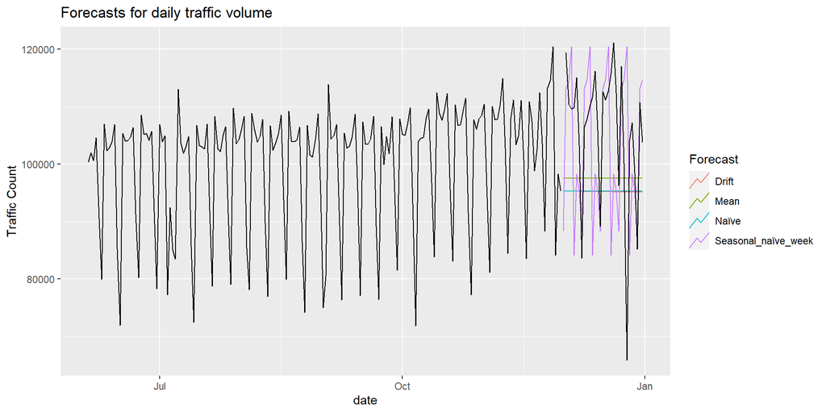

```r
baseline_fit <- train |> filter(Travel_Dir == '3') |>
                model(Mean = MEAN(daily_volume),
                      `Naïve` = NAIVE(daily_volume),
                      `Seasonal_naïve_week` = SNAIVE(daily_volume ~ lag('week')),
                       Drift = NAIVE(daily_volume ~ drift())
                     )

# Generate forecasts for 14 quarters
baseline_fc <- baseline_fit |> forecast(h = 31)
# Plot forecasts against actual values
baseline_fc |>
  autoplot(train |> filter(Travel_Dir == '3') |> tail(30*6), level = NULL) +
  autolayer(
    filter_index(test |> filter(Travel_Dir == '3'), "2019-12-02" ~ "2019-12-31"),
    colour = "black"
  ) +
  labs(
    y = "Traffic Count",
    title = "Forecasts for daily traffic volume"
  ) +
  guides(colour = guide_legend(title = "Forecast"))
```

```r
accuracy( baseline_fc, df|> filter(Travel_Dir == '3')) |> select(.model, MAPE, RMSE, RMSSE)
```

| .model | MAPE | RMSE | RMSSE |
| --- | --- | --- | --- |
| Drift | 13.33265 | 15538.88 | 2.078533 |
| Mean | 12.06426 | 14109.02 | 1.887269 |
| Naïve | 13.27572 | 15483.25 | 2.071091 |
| Seasonal_naïve_week | 12.17263 | 16486.27 | 2.205258 |

So, the ‘mean’ model performs best.

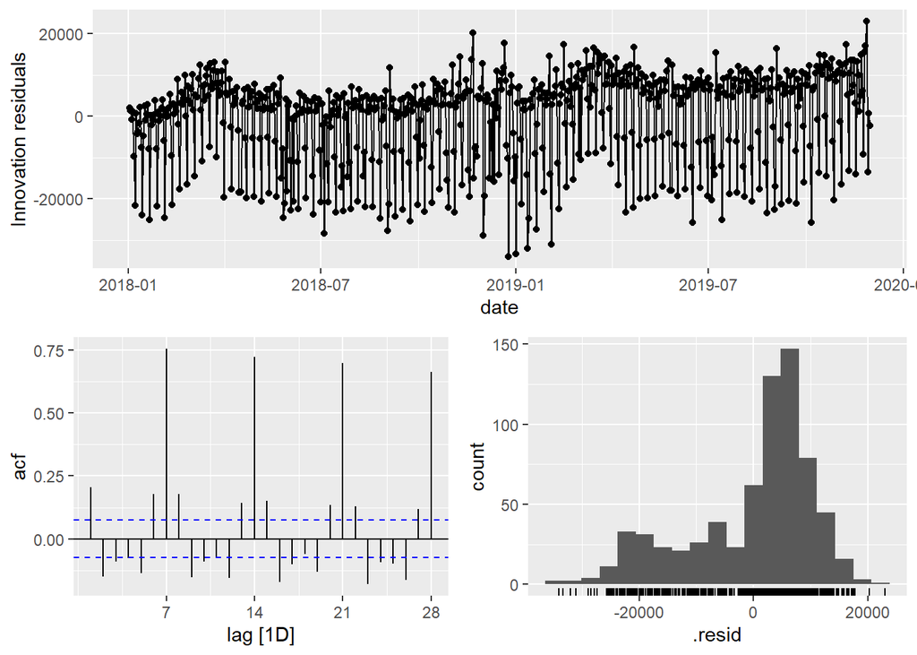

```r
baseline_fit |> select(Mean) |> gg_tsresiduals()
```

# Linear Regression

```r
dummy_vars <- model.matrix(~ week_of_month + day_of_week + month - 1, data = train)
train_reg <- cbind(train, dummy_vars) |> select(-week_of_month, -day_of_week, -month)
head(train_reg)
```

| Travel_Dir | date | daily_volume | is_holiday | is_long_weekend | is_thanksgiving_week | is_christmas_week | is_new_year_season | is_long_weekend_lag2 | is_long_weekend_lag1 | is_long_weekend_lead2 | is_long_weekend_lead1 | is_holiday_lag1 | is_holiday_lead1 | daily_volume_lag1 | daily_volume_lag2 | daily_volume_lag3 | daily_volume_lag4 | daily_volume_lag5 | daily_volume_lag6 | daily_volume_lag7 | week_of_month1 | week_of_month2 | week_of_month3 | week_of_month4 | week_of_month5 | week_of_month6 | day_of_week.L | day_of_week.Q | day_of_week.C | … |
| --- | --- | --- | --- | --- | --- | --- | --- | --- | --- | --- | --- | --- | --- | --- | --- | --- | --- | --- | --- | --- | --- | --- | --- | --- | --- | --- | --- | --- | --- | --- |
| 3 | 2018-01-02 | 99589 | 0 | 0 | 0 | 0 | 1 | -1 | -1 | 0 | 0 | -1 | 0 | -1 | -1 | -1 | -1 | -1 | -1 | -1 | 1 | 0 | 0 | 0 | 0 | 0 | -1.889822e-01 | -0.3273268 | 4.082483e-01 | … |
| 3 | 2018-01-03 | 98978 | 0 | 0 | 0 | 0 | 1 | -1 | 0 | 0 | 0 | 0 | 0 | 99589 | -1 | -1 | -1 | -1 | -1 | -1 | 1 | 0 | 0 | 0 | 0 | 0 | 2.098124e-17 | -0.4364358 | 4.532467e-17 | … |
| 3 | 2018-01-04 | 96857 | 0 | 0 | 0 | 0 | 0 | 0 | 0 | 0 | 0 | 0 | 0 | 98978 | 99589 | -1 | -1 | -1 | -1 | -1 | 1 | 0 | 0 | 0 | 0 | 0 | 1.889822e-01 | -0.3273268 | -4.082483e-01 | … |
| 3 | 2018-01-05 | 98756 | 0 | 0 | 0 | 0 | 0 | 0 | 0 | 0 | 0 | 0 | 0 | 96857 | 98978 | 99589 | -1 | -1 | -1 | -1 | 1 | 0 | 0 | 0 | 0 | 0 | 3.779645e-01 | 0.0000000 | -4.082483e-01 | … |
| 3 | 2018-01-06 | 87891 | 0 | 0 | 0 | 0 | 0 | 0 | 0 | 0 | 0 | 0 | 0 | 98756 | 96857 | 98978 | 99589 | -1 | -1 | -1 | 1 | 0 | 0 | 0 | 0 | 0 | 5.669467e-01 | 0.5455447 | 4.082483e-01 | … |
| 3 | 2018-01-07 | 75906 | 0 | 0 | 0 | 0 | 0 | 0 | 0 | 0 | 0 | 0 | 0 | 87891 | 98756 | 96857 | 98978 | 99589 | -1 | -1 | 1 | 0 | 0 | 0 | 0 | 0 | -5.669467e-01 | 0.5455447 | -4.082483e-01 | … |

```r
train_sample <- train_reg |> filter(Travel_Dir == 3)
head(train_sample)
```

| Travel_Dir | date | daily_volume | is_holiday | is_long_weekend | is_thanksgiving_week | is_christmas_week | is_new_year_season | is_long_weekend_lag2 | is_long_weekend_lag1 | is_long_weekend_lead2 | is_long_weekend_lead1 | is_holiday_lag1 | is_holiday_lead1 | daily_volume_lag1 | daily_volume_lag2 | daily_volume_lag3 | daily_volume_lag4 | daily_volume_lag5 | daily_volume_lag6 | daily_volume_lag7 | week_of_month1 | week_of_month2 | week_of_month3 | week_of_month4 | week_of_month5 | week_of_month6 | day_of_week.L | day_of_week.Q | day_of_week.C | … |
| --- | --- | --- | --- | --- | --- | --- | --- | --- | --- | --- | --- | --- | --- | --- | --- | --- | --- | --- | --- | --- | --- | --- | --- | --- | --- | --- | --- | --- | --- | --- |
| 3 | 2018-01-02 | 99589 | 0 | 0 | 0 | 0 | 1 | -1 | -1 | 0 | 0 | -1 | 0 | -1 | -1 | -1 | -1 | -1 | -1 | -1 | 1 | 0 | 0 | 0 | 0 | 0 | -1.889822e-01 | -0.3273268 | 4.082483e-01 | … |
| 3 | 2018-01-03 | 98978 | 0 | 0 | 0 | 0 | 1 | -1 | 0 | 0 | 0 | 0 | 0 | 99589 | -1 | -1 | -1 | -1 | -1 | -1 | 1 | 0 | 0 | 0 | 0 | 0 | 2.098124e-17 | -0.4364358 | 4.532467e-17 | … |
| 3 | 2018-01-04 | 96857 | 0 | 0 | 0 | 0 | 0 | 0 | 0 | 0 | 0 | 0 | 0 | 98978 | 99589 | -1 | -1 | -1 | -1 | -1 | 1 | 0 | 0 | 0 | 0 | 0 | 1.889822e-01 | -0.3273268 | -4.082483e-01 | … |
| 3 | 2018-01-05 | 98756 | 0 | 0 | 0 | 0 | 0 | 0 | 0 | 0 | 0 | 0 | 0 | 96857 | 98978 | 99589 | -1 | -1 | -1 | -1 | 1 | 0 | 0 | 0 | 0 | 0 | 3.779645e-01 | 0.0000000 | -4.082483e-01 | … |
| 3 | 2018-01-06 | 87891 | 0 | 0 | 0 | 0 | 0 | 0 | 0 | 0 | 0 | 0 | 0 | 98756 | 96857 | 98978 | 99589 | -1 | -1 | -1 | 1 | 0 | 0 | 0 | 0 | 0 | 5.669467e-01 | 0.5455447 | 4.082483e-01 | … |
| 3 | 2018-01-07 | 75906 | 0 | 0 | 0 | 0 | 0 | 0 | 0 | 0 | 0 | 0 | 0 | 87891 | 98756 | 96857 | 98978 | 99589 | -1 | -1 | 1 | 0 | 0 | 0 | 0 | 0 | -5.669467e-01 | 0.5455447 | -4.082483e-01 | … |

```r
library(leaps)
back <- regsubsets(daily_volume ~ . -daily_volume -Travel_Dir -week_of_month6 -date, data = train_sample, nvmax=40, method="backward")
coefficient.regfitBack <- coef(back, 1:40)

train.mat <- model.matrix(daily_volume ~ . -daily_volume -Travel_Dir -week_of_month6 -date, data = train_sample)
trainErrorBackward = rep(NA, 40)
for (i in 1:40) {
  coefficient = coef(back, id=i)
  prediction = train.mat[,names(coefficient)]%*%coefficient
  trainErrorBackward[i] = mean((train_sample$daily_volume - prediction)^2)
}
cat("Training errors:\n")
```

```
## Training errors:
```

```r
trainErrorBackward
```

```
##  [1] 71439419 56291482 45677999 39346921 34814558 31950003 31107585 29646426
##  [9] 28164852 27126011 26474808 26070776 25653386 25433415 25292765 25110961
## [17] 24988427 24877207 24771849 24687848 24617812 24551992 24515415 24482608
## [25] 24427736 24385780 24351557 24324469 24296180 24271966 24257785 24243022
## [33] 24238082 24235126 24233397 24233339 24233302 24233275 24233251 24233244
```

```r
nTrain = nrow(train_sample)
linreg.bic = nTrain*log(trainErrorBackward) + log(nTrain)*c(seq(2,41,1))
linreg.bic
```

```
##  [1] 12635.98 12476.19 12336.91 12239.32 12160.44 12107.06 12094.95 12067.92
##  [9] 12038.68 12019.00 12008.59 12004.40 11999.68 12000.22 12002.90 12004.41
## [17] 12007.55 12010.98 12014.57 12018.74 12023.31 12027.99 12033.50 12039.11
## [25] 12044.09 12049.44 12055.01 12060.78 12066.52 12072.37 12078.51 12084.63
## [33] 12091.04 12097.50 12104.00 12110.55 12117.09 12123.64 12130.19 12136.74
```

```r
bestlinreg.bic = which.min(linreg.bic)
bestlinreg.bic
```

```
## [1] 13
```

```r
bestcoeff.bic = coef(back,id=bestlinreg.bic)
cat("The selected variables according to BIC criteria:\n")
```

```
## The selected variables according to BIC criteria:
```

```r
names(bestcoeff.bic)
```

```
##  [1] "(Intercept)"           "is_holiday"            "is_long_weekend"
##  [4] "is_long_weekend_lead2" "daily_volume_lag1"     "day_of_week.L"
##  [7] "day_of_week.Q"         "day_of_week.C"         "`day_of_week^4`"
## [10] "`day_of_week^5`"       "`day_of_week^6`"       "month.C"
## [13] "`month^4`"             "`month^7`"
```

```r
linreg.aic <- nTrain*log(trainErrorBackward) + 2*c(seq(2,41,1))
linreg.aic
```

```
##  [1] 12626.88 12462.55 12318.71 12216.57 12133.15 12075.22 12058.57 12026.99
##  [9] 11993.20 11968.97 11954.01 11945.28 11936.01 11932.00 11930.13 11927.09
## [17] 11925.68 11924.56 11923.60 11923.23 11923.25 11923.38 11924.34 11925.40
## [25] 11925.84 11926.64 11927.66 11928.88 11930.07 11931.37 11932.97 11934.54
## [33] 11936.40 11938.31 11940.26 11942.26 11944.26 11946.26 11948.26 11950.26
```

```r
bestlinreg.aic = which.min(linreg.aic)
bestlinreg.aic
```

```
## [1] 20
```

```r
bestcoeff.aic = coef(back,id=bestlinreg.aic)
cat("The selected variables according to AIC criteria:\n")
```

```
## The selected variables according to AIC criteria:
```

```r
names(bestcoeff.aic)
```

```
##  [1] "(Intercept)"           "is_holiday"            "is_long_weekend"
##  [4] "is_thanksgiving_week"  "is_new_year_season"    "is_long_weekend_lag2"
##  [7] "is_long_weekend_lag1"  "is_long_weekend_lead2" "daily_volume_lag1"
## [10] "daily_volume_lag6"     "week_of_month1"        "day_of_week.L"
## [13] "day_of_week.Q"         "day_of_week.C"         "`day_of_week^4`"
## [16] "`day_of_week^5`"       "`day_of_week^6`"       "month.C"
## [19] "`month^4`"             "`month^7`"             "`month^8`"
```

```r
tsregFormula.bic <- as.formula(paste("daily_volume ~ trend() + ", paste0(names(bestcoeff.bic)[-1], collapse = " + ")))
tsregFormula.bic
```

```
## daily_volume ~ trend() + is_holiday + is_long_weekend + is_long_weekend_lead2 +
##     daily_volume_lag1 + day_of_week.L + day_of_week.Q + day_of_week.C +
##     `day_of_week^4` + `day_of_week^5` + `day_of_week^6` + month.C +
##     `month^4` + `month^7`
```

```r
fit_linreg.bic <- train_reg |>
  model(tslm = TSLM(tsregFormula.bic))
```

```r
fit_linreg.bic |> filter(Travel_Dir == 3) |> report()
```

```
## Series: daily_volume
## Model: TSLM
##
## Residuals:
##      Min       1Q   Median       3Q      Max
## -28607.7  -1285.5    347.1   1967.6  24664.2
##
## Coefficients:
##                         Estimate Std. Error t value Pr(>|t|)
## (Intercept)            8.490e+04  2.580e+03  32.906  < 2e-16 ***
## trend()                8.877e+00  9.709e-01   9.143  < 2e-16 ***
## is_holiday            -2.516e+04  1.853e+03 -13.575  < 2e-16 ***
## is_long_weekend        1.342e+04  2.288e+03   5.866 6.96e-09 ***
## is_long_weekend_lead2  4.800e+03  1.331e+03   3.605 0.000335 ***
## daily_volume_lag1      1.020e-01  2.729e-02   3.738 0.000201 ***
## day_of_week.L          5.912e+03  6.616e+02   8.936  < 2e-16 ***
## day_of_week.Q         -1.852e+04  5.025e+02 -36.860  < 2e-16 ***
## day_of_week.C          4.475e+03  5.081e+02   8.808  < 2e-16 ***
## `day_of_week^4`       -1.219e+04  5.730e+02 -21.269  < 2e-16 ***
## `day_of_week^5`        3.110e+03  5.462e+02   5.694 1.84e-08 ***
## `day_of_week^6`       -2.478e+03  5.044e+02  -4.912 1.13e-06 ***
## month.C                3.633e+03  6.830e+02   5.319 1.42e-07 ***
## `month^4`             -5.601e+03  6.767e+02  -8.276 6.66e-16 ***
## `month^7`             -2.925e+03  6.289e+02  -4.651 3.97e-06 ***
## ---
## Signif. codes:  0 '***' 0.001 '**' 0.01 '*' 0.05 '.' 0.1 ' ' 1
##
## Residual standard error: 4833 on 683 degrees of freedom
## Multiple R-squared: 0.8059,  Adjusted R-squared: 0.802
## F-statistic: 202.6 on 14 and 683 DF, p-value: < 2.22e-16
```

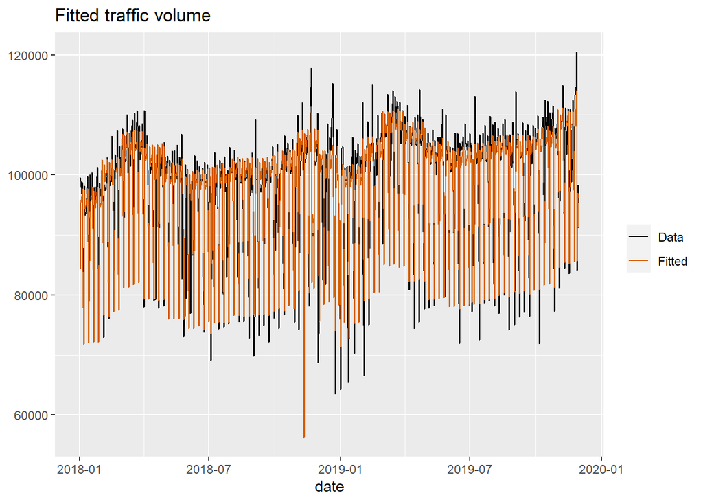

```r
fit_linreg.bic |> filter(Travel_Dir == 3) |> augment() |>
  ggplot(aes(x = date)) +
  geom_line(aes(y = daily_volume, colour = "Data")) +
  geom_line(aes(y = .fitted, colour = "Fitted")) +
  labs(y = NULL,
    title = "Fitted traffic volume"
  ) +
  scale_colour_manual(values=c(Data="black",Fitted="#D55E00")) +
  guides(colour = guide_legend(title = NULL))
```

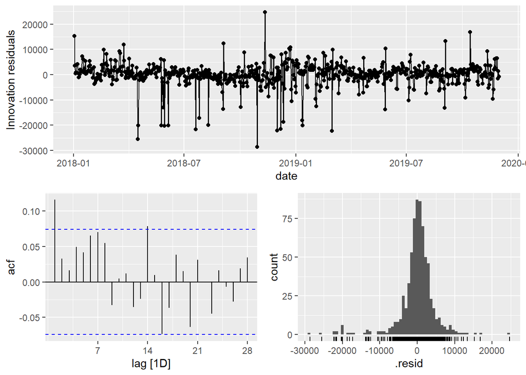

```r
fit_linreg.bic |> filter(Travel_Dir == 3) |> gg_tsresiduals()
```

```r
fit_linreg.bic |> augment() |>
  features(.innov, ljung_box, lag = 14)
```

| Travel_Dir | .model | lb_stat | lb_pvalue |
| --- | --- | --- | --- |
| 3 | tslm | 28.60494 | 1.181352e-02 |
| 7 | tslm | 46.46687 | 2.351394e-05 |

As p-value is less than 0.05, we conclude that the residuals are significantly distinguishable from the white noise.

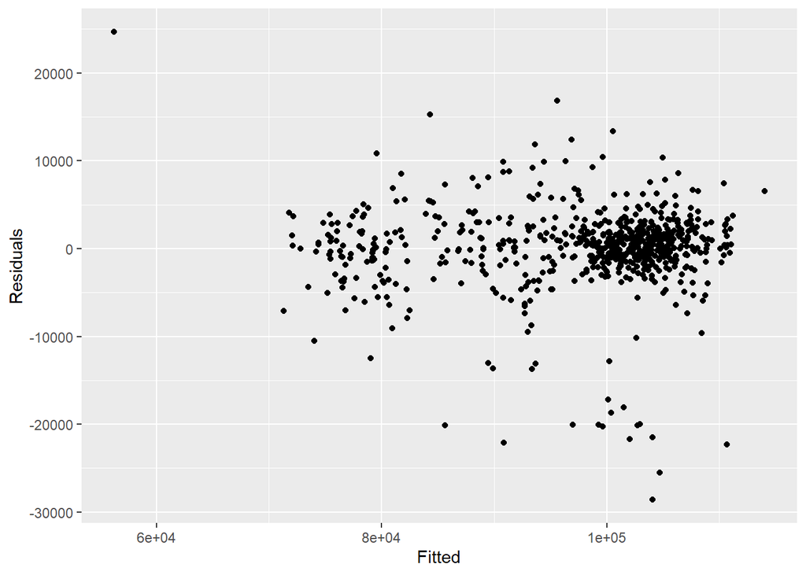

```r
fit_linreg.bic |> filter(Travel_Dir == 3) |> augment() |>
  ggplot(aes(x = .fitted, y = .resid)) +
  geom_point() + labs(x = "Fitted", y = "Residuals")
```

```r
dummy_vars <- model.matrix(~ week_of_month + day_of_week + month - 1, data = test)
test_reg <- cbind(test, dummy_vars) |> select(-week_of_month, -day_of_week, -month)
```

```r
linreg.bic.fc <- fit_linreg.bic |> forecast(new_data = test_reg)
accuracy(linreg.bic.fc, df) |> select(.model, MAPE, RMSSE)
```

| .model | MAPE | RMSSE |
| --- | --- | --- |
| tslm | 7.522782 | 1.272669 |
| tslm | 6.675894 | 1.165392 |

```r
tsregFormula.aic <- as.formula(paste("daily_volume ~ trend() + ", paste0(names(bestcoeff.aic)[-1], collapse = " + ")))
tsregFormula.aic
```

```
## daily_volume ~ trend() + is_holiday + is_long_weekend + is_thanksgiving_week +
##     is_new_year_season + is_long_weekend_lag2 + is_long_weekend_lag1 +
##     is_long_weekend_lead2 + daily_volume_lag1 + daily_volume_lag6 +
##     week_of_month1 + day_of_week.L + day_of_week.Q + day_of_week.C +
##     `day_of_week^4` + `day_of_week^5` + `day_of_week^6` + month.C +
##     `month^4` + `month^7` + `month^8`
```

```r
fit_linreg.aic <- train_reg |>
  model(tslm = TSLM(tsregFormula.aic))
```

```r
fit_linreg.aic |> filter(Travel_Dir == 7) |> report()
```

```
## Series: daily_volume
## Model: TSLM
##
## Residuals:
##    Min     1Q Median     3Q    Max
## -34758  -1466    275   2117  14590
##
## Coefficients:
##                         Estimate Std. Error t value Pr(>|t|)
## (Intercept)            5.626e+04  4.319e+03  13.025  < 2e-16 ***
## trend()                6.424e+00  1.093e+00   5.878 6.52e-09 ***
## is_holiday            -1.789e+04  2.085e+03  -8.578  < 2e-16 ***
## is_long_weekend        1.179e+04  2.512e+03   4.692 3.28e-06 ***
## is_thanksgiving_week   2.423e+03  1.579e+03   1.535 0.125323
## is_new_year_season    -1.343e+03  1.820e+03  -0.738 0.460833
## is_long_weekend_lag2  -3.268e+03  1.501e+03  -2.177 0.029839 *
## is_long_weekend_lag1  -8.419e+02  1.484e+03  -0.567 0.570722
## is_long_weekend_lead2  4.720e+03  1.465e+03   3.222 0.001334 **
## daily_volume_lag1      2.160e-01  3.515e-02   6.146 1.36e-09 ***
## daily_volume_lag6      1.643e-01  3.310e-02   4.965 8.72e-07 ***
## week_of_month1        -9.516e+02  6.085e+02  -1.564 0.118302
## day_of_week.L          1.252e+04  7.640e+02  16.383  < 2e-16 ***
## day_of_week.Q         -1.076e+04  8.437e+02 -12.755  < 2e-16 ***
## day_of_week.C         -1.813e+02  6.410e+02  -0.283 0.777361
## `day_of_week^4`       -6.203e+03  6.069e+02 -10.222  < 2e-16 ***
## `day_of_week^5`       -1.522e+03  5.584e+02  -2.726 0.006569 **
## `day_of_week^6`       -1.837e+03  5.515e+02  -3.331 0.000914 ***
## month.C                2.825e+03  7.584e+02   3.725 0.000211 ***
## `month^4`             -4.285e+03  7.789e+02  -5.501 5.37e-08 ***
## `month^7`             -1.291e+03  6.892e+02  -1.874 0.061373 .
## `month^8`              3.891e+02  6.697e+02   0.581 0.561420
## ---
## Signif. codes:  0 '***' 0.001 '**' 0.01 '*' 0.05 '.' 0.1 ' ' 1
##
## Residual standard error: 5176 on 676 degrees of freedom
## Multiple R-squared: 0.753,   Adjusted R-squared: 0.7454
## F-statistic: 98.15 on 21 and 676 DF, p-value: < 2.22e-16
```

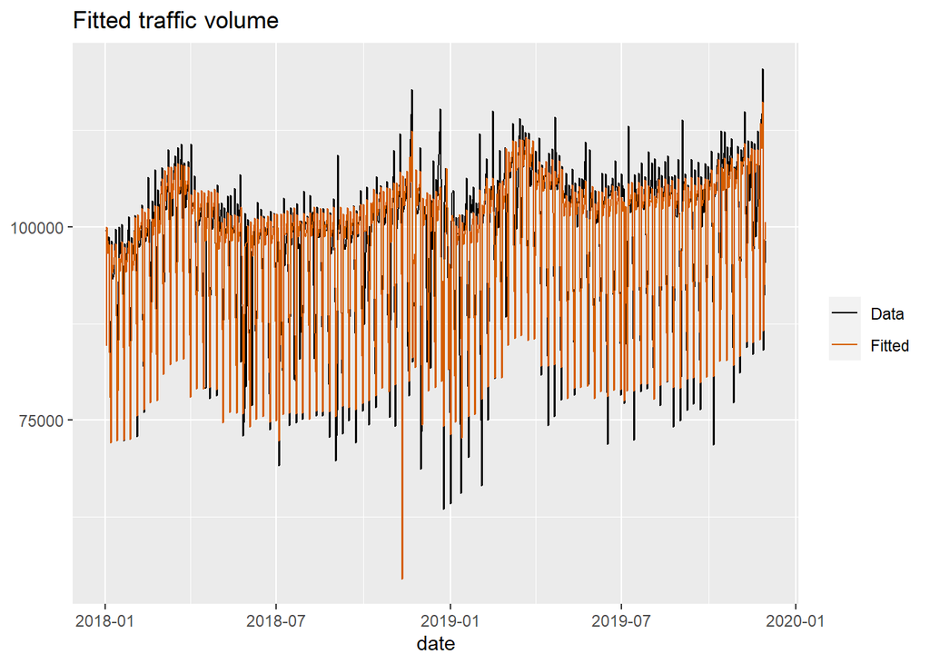

```r
fit_linreg.aic |> filter(Travel_Dir == 3) |> augment() |>
  ggplot(aes(x = date)) +
  geom_line(aes(y = daily_volume, colour = "Data")) +
  geom_line(aes(y = .fitted, colour = "Fitted")) +
  labs(y = NULL,
    title = "Fitted traffic volume"
  ) +
  scale_colour_manual(values=c(Data="black",Fitted="#D55E00")) +
  guides(colour = guide_legend(title = NULL))
```

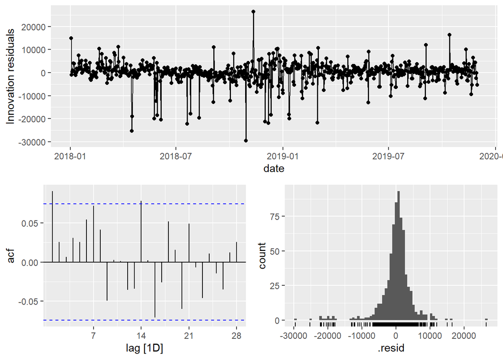

```r
fit_linreg.aic |> filter(Travel_Dir == 3) |> gg_tsresiduals()
```

```r
fit_linreg.aic |> augment() |>
  features(.innov, ljung_box, lag = 14)
```

| Travel_Dir | .model | lb_stat | lb_pvalue |
| --- | --- | --- | --- |
| 3 | tslm | 21.97060 | 0.07922053 |
| 7 | tslm | 24.27206 | 0.04247173 |

As p-value is less than 0.05 for Travel_Dir 7, we conclude that the residuals for that series are significantly distinguishable from the white noise.

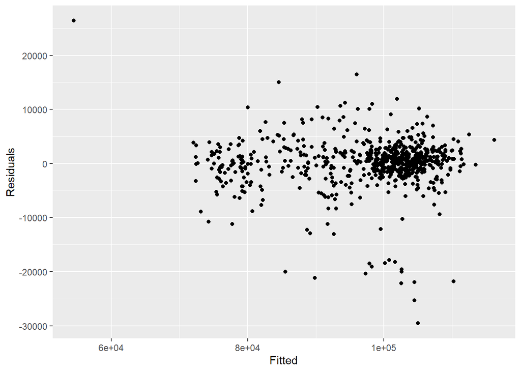

```r
fit_linreg.aic |> filter(Travel_Dir == 3) |> augment() |>
  ggplot(aes(x = .fitted, y = .resid)) +
  geom_point() + labs(x = "Fitted", y = "Residuals")
```

```r
linreg.aic.fc <- fit_linreg.aic |> forecast(new_data = test_reg)
accuracy(linreg.aic.fc, df) |> select(.model, MAPE, RMSSE)
```

| .model | MAPE | RMSSE |
| --- | --- | --- |
| tslm | 7.103622 | 1.249068 |
| tslm | 6.717677 | 1.256243 |